# Lojistik Regresyon ile Destek Vektör Makinelerinin Karşılaştırılması

Halil Görkem Herek

## Lojistik Regresyon

Lojistik regresyon, sınıflandırma problemlerinde kullanılan bir istatistiksel modeldir. Lojistik regresyon, bağımsız değişkenlerin verildiği durumlarda bir bağımlı değişkenin iki sınıfa ait olma olasılığını tahmin etmek için kullanılır. Örneğin, hasta/hasta olmayan, evet/hayır gibi iki sınıfı olan problemlerde sıklıkla tercih edilir. Lojistik regresyon çıktı olarak 0 ile 1 arasında olasılık değerleri verir ve bu değerlerin üzerine belirli bir eşik değeri uygulanarak sınıflandırma yapılabilir.

## Destek Vektör Makineleri (SVM)

Destek vektör makineleri, hem sınıflandırma hem de regresyon problemleri için kullanılan güçlü bir makine öğrenme algoritmasıdır. SVM, veri noktalarını sınıflandırmak veya bir çizgiye uygun bir şekilde oturtmak için kullanılır. SVM, verileri yüksek boyutlu uzayda temsil eder ve bu uzayda sınıflandırma yapabilmek için optimum bir hiperdüzlem bulmaya çalışır. Sınıflar arasındaki ayrımı maksimuma çıkarmak için destek vektörleri kullanır.

Şimdi, R programı kullanarak lojistik regresyon ve destek vektör makinelerini bir veri seti üzerinde karşılaştırma yapalım.

Bunun için kaggle’dan elde ettiğimiz Pima Kızılderilileri Diyabet Veritabanını kullanacağız.

Bu veri kümesi aslen Ulusal Diyabet ve Sindirim ve Böbrek Hastalıkları Enstitüsü’ndendir. Veri setinin amacı, veri setinde yer alan belirli teşhis ölçümlerine dayalı olarak bir hastanın diyabet hastası olup olmadığını teşhis amaçlı olarak tahmin etmektir. Buradaki tüm hastalar en az 21 yaşında Pima Kızılderili mirasına sahip kadınlardır. Veri kümesi, 9 sütundan ve 768 gözlemden oluşmaktadır. Veri setini anlamak için sütunlarımızı tanımlayalım.

- Pregnancies : Hamile kalma sayısı
- Glucose : Oral glukoz tolerans testinde 2 saatlik plazma glukoz konsantrasyonu
- BloodPressure : Diyastolik kan basıncı (mm Hg)
- SkinThickness : Triceps deri kıvrım kalınlığı (mm)
- Insulin : 2 saatlik serum insülini (mu U/ml)
- BMI : Vücut kitle indeksi
- DiabetesPedigreeFunction : Diyabet soy ağacı işlevi
- Age : Yaş
- Outcome : Sınıf değişkeni (0 veya 1) 768’den 268’i 1, diğerleri 0

Şimdi verimizi R’ye aktaralım ve ilk birkaç gözleme bakalım.

```r
diabetes_data <- read.csv("diabetes.csv")
head(diabetes_data)
```

```
##   Pregnancies Glucose BloodPressure SkinThickness Insulin  BMI
## 1           6     148            72            35       0 33.6
## 2           1      85            66            29       0 26.6
## 3           8     183            64             0       0 23.3
## 4           1      89            66            23      94 28.1
## 5           0     137            40            35     168 43.1
## 6           5     116            74             0       0 25.6
##   DiabetesPedigreeFunction Age Outcome
## 1                    0.627  50       1
## 2                    0.351  31       0
## 3                    0.672  32       1
## 4                    0.167  21       0
## 5                    2.288  33       1
## 6                    0.201  30       0
```

Veri setimizin yapısal özelliklerine bakalım.

```r
str(diabetes_data)
```

```
## 'data.frame':    768 obs. of  9 variables:
##  $ Pregnancies             : int  6 1 8 1 0 5 3 10 2 8 ...
##  $ Glucose                 : int  148 85 183 89 137 116 78 115 197 125 ...
##  $ BloodPressure           : int  72 66 64 66 40 74 50 0 70 96 ...
##  $ SkinThickness           : int  35 29 0 23 35 0 32 0 45 0 ...
##  $ Insulin                 : int  0 0 0 94 168 0 88 0 543 0 ...
##  $ BMI                     : num  33.6 26.6 23.3 28.1 43.1 25.6 31 35.3 30.5 0 ...
##  $ DiabetesPedigreeFunction: num  0.627 0.351 0.672 0.167 2.288 ...
##  $ Age                     : int  50 31 32 21 33 30 26 29 53 54 ...
##  $ Outcome                 : int  1 0 1 0 1 0 1 0 1 1 ...
```

Veri setimizin özet istatistiklerini görüntüleyelim.

```r
summary(diabetes_data)
```

```
##   Pregnancies        Glucose      BloodPressure    SkinThickness
##  Min.   : 0.000   Min.   :  0.0   Min.   :  0.00   Min.   : 0.00
##  1st Qu.: 1.000   1st Qu.: 99.0   1st Qu.: 62.00   1st Qu.: 0.00
##  Median : 3.000   Median :117.0   Median : 72.00   Median :23.00
##  Mean   : 3.845   Mean   :120.9   Mean   : 69.11   Mean   :20.54
##  3rd Qu.: 6.000   3rd Qu.:140.2   3rd Qu.: 80.00   3rd Qu.:32.00
##  Max.   :17.000   Max.   :199.0   Max.   :122.00   Max.   :99.00
##     Insulin           BMI        DiabetesPedigreeFunction      Age
##  Min.   :  0.0   Min.   : 0.00   Min.   :0.0780           Min.   :21.00
##  1st Qu.:  0.0   1st Qu.:27.30   1st Qu.:0.2437           1st Qu.:24.00
##  Median : 30.5   Median :32.00   Median :0.3725           Median :29.00
##  Mean   : 79.8   Mean   :31.99   Mean   :0.4719           Mean   :33.24
##  3rd Qu.:127.2   3rd Qu.:36.60   3rd Qu.:0.6262           3rd Qu.:41.00
##  Max.   :846.0   Max.   :67.10   Max.   :2.4200           Max.   :81.00
##     Outcome
##  Min.   :0.000
##  1st Qu.:0.000
##  Median :0.000
##  Mean   :0.349
##  3rd Qu.:1.000
##  Max.   :1.000
```

Makine öğrenimi modellerini eğitmek ve performansını değerlendirmek için eğitim ve test veri setleri oluşturalım.

```r
set.seed(123)
train_indices <- sample(1:nrow(diabetes_data), 0.7 * nrow(diabetes_data))
train_data <- diabetes_data[train_indices, ]
test_data <- diabetes_data[-train_indices, ]
```

Bağımsız değişkenler arasındaki korelasyonu görmek için bir korelasyon matrisi çizdirelim.

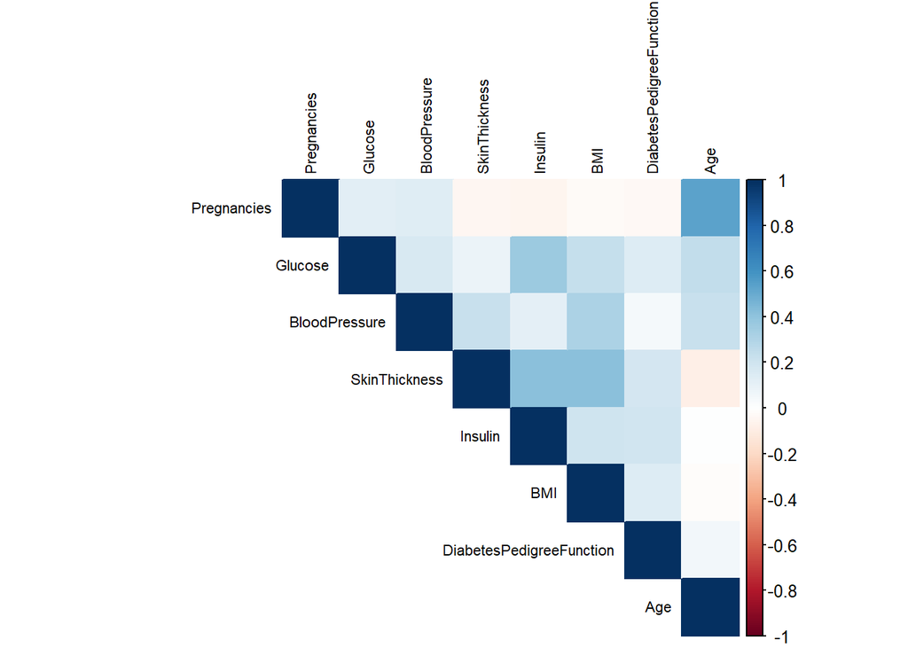

```r
library(corrplot)
cor_matrix <- cor(train_data[, -9])
corrplot(cor_matrix, method = "color", type = "upper", tl.cex = 0.7, tl.col = "black")
```

Veri setimizdeki şeker hastası ve sağlıklı bireylerin dağılımına bakalım.

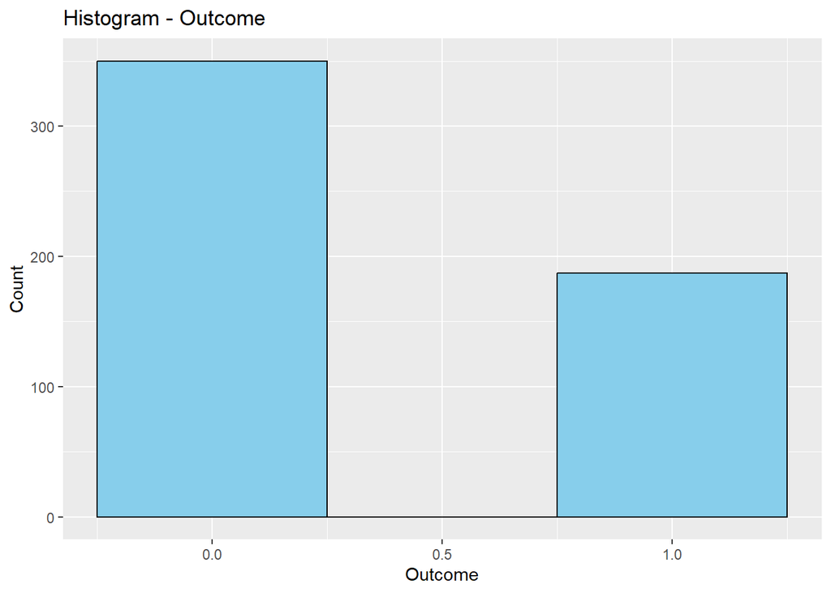

```r
library(ggplot2)
ggplot(train_data, aes(x = Outcome)) +
  geom_histogram(binwidth = 0.5, fill = "skyblue", color = "black") +
  labs(x = "Outcome", y = "Count", title = "Histogram - Outcome")
```

Lojistik Regresyon modelimizi oluşturalım. Burada ‘glmnet’ paketini kullanacağız. glmnet paketi, istatistiksel modelleme ve makine öğrenimi alanında sıkça kullanılan bir araçtır. Hem regresyon hem de sınıflandırma problemleri için kullanılabilir ve değişken seçimi ve regülarizasyon gibi önemli konuları ele alırken, modelin performansını artırmaya yardımcı olur.

```r
library(glmnet)
# Bağımlı değişkeni ve bağımsız değişkenleri ayırma
y_train <- train_data$Outcome
x_train <- train_data[, -9]

# Veriyi standartlaştırma
x_train <- scale(x_train)

# Lojistik regresyon modelini oluşturma
model_logit <- glmnet(x_train, y_train, family = "binomial", alpha = 1)
```

Şimdi ise Destek Vektör Makineleri modelimizi oluşturalım. bunun için ‘e1071’ paketini kullanacağız. e1071 paketi, hem akademik araştırmalarda hem de endüstriyel uygulamalarda destek vektör makineleri yöntemini kullanmak isteyen kullanıcılara kolaylık sağlar. Veri sınıflandırma ve regresyon problemlerini çözmek için güçlü ve esnek bir araç sunar.

```r
library(e1071)

# Destek vektör makineleri modelini oluşturma
model_svm <- svm(Outcome ~ ., data = train_data, kernel = "linear", probability = TRUE)
```

Burada oluşturduğumuz modelleri kullanarak test veri seti üzerinde tahmin yapalım. Aynnı zamanda lojistik regresyon tahminlerinin uzunluğunu test veri setinin ‘Outcome’ sütununun uzunluğuna ayarlayalım.

```r
# Test veri seti üzerinde tahmini
x_test <- test_data[, -9]

# Lojistik regresyon ile tahmini
x_test_scaled <- scale(x_test)
predicted_logit <- predict(model_logit, newx = x_test_scaled, type = "response")

# Destek vektör makineleri ile tahmini
predicted_svm <- predict(model_svm, newdata = x_test, probability = TRUE, type = "response")

# predicted_logit uzunluğunu test_data$Outcome uzunluğuna ayarla
predicted_logit <- predicted_logit[1:length(test_data$Outcome)]
```

Şimdi ise oluşturduğumuz lojistik regresyon ve destek vektör makineleri modelleri için ROC eğrilerini çizdirelim. ROC (Receiver Operating Characteristic) eğrisi, bir sınıflandırma modelinin performansını değerlendirmek için kullanılan bir grafiksel araçtır. Özellikle ikili sınıflandırma problemlerinde yaygın olarak kullanılır.

```r
library(pROC)
roc_logit <- roc(test_data$Outcome, predicted_logit)
roc_svm <- roc(test_data$Outcome, predicted_svm)
```

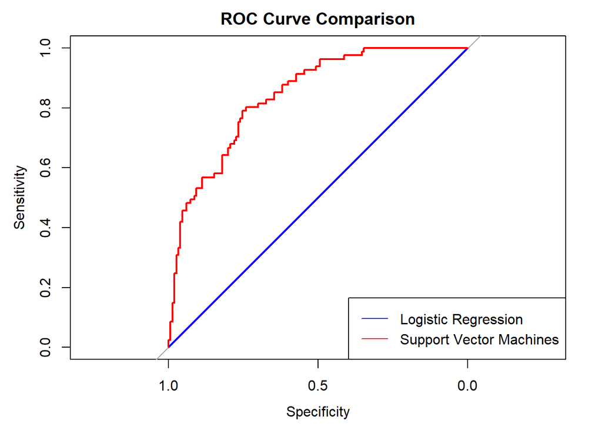

```r
plot(roc_logit, col = "blue", main = "ROC Curve Comparison")
lines(roc_svm, col = "red")
legend("bottomright", legend = c("Logistic Regression", "Support Vector Machines"), col = c("blue", "red"), lty = 1)
```

Son olarak AUC değerlerine göz atalım. AUC değeri, ROC eğrisinin altında kalan alanı ifade eder ve bir sınıflandırma modelinin performansını ölçmek için kullanılır.

```r
# AUC değerlerini elde etmek için
auc_logit <- auc(roc_logit)
auc_svm <- auc(roc_svm)

# Modellerin karşılaştırmasını yapmak için AUC değerlerini yazdır
print(paste("Logistic Regression AUC:", auc_logit))
```

```
## [1] "Logistic Regression AUC: 0.5"
```

```r
print(paste("Support Vector Machines AUC:", auc_svm))
```

```
## [1] "Support Vector Machines AUC: 0.840576131687243"
```

Bu durumda, lojistik regresyon modeli için AUC değeri 0.5 olarak görünüyor, yani model rasgele tahmin yapmaktan daha iyi bir performans sergilemiyor. Diğer yandan, destek vektör makineleri (SVM) modeli için AUC değeri 0.840576131687243 olarak hesaplanmış. Bu durumda SVM modelinin, rasgele tahmin yapmaktan daha iyi bir performans sergilediği söylenebilir.

AUC değeri, bir modelin sınıflandırma performansını ölçen ve 1’e yaklaştıkça daha iyi performansı gösterdiğini gösteren bir metriktir. Dolayısıyla, SVM modelinin AUC değerinin 0.84 olması, modelin iyi bir ayrımcı yetenek sergilediğini ve veri setindeki hastaların şeker hastası olup olmadığını daha doğru bir şekilde tahmin ettiğini göstermektedir.

### Referanslar :

[DİYABET VERİ SETİ](https://www.kaggle.com/datasets/uciml/pima-indians-diabetes-database)